# assignment

Ieva Gudelytė

2026-03-18

```r
suppressPackageStartupMessages({
  library(AnnotationHub)
  library(ensembldb)
  library(GenomicRanges)
  library(epiwraps)
  library(rtracklayer)
  library(ggplot2)
  library(GenomeInfoDb) # for matching chromosome naming styles
})
ah <- AnnotationHub()
```

# Downloading the data

From ENCODE, we download peak data (i.e. in bed-like format) for p300, H3K27ac, and H3K27me3 in mouse embryonic stem cells (mESC, ES-Bruce4) and in a differentiated tissue (heart) from 2-month-old male adult mice. Mapping assembly: mm10. When available, “conservative IDR thresholded peaks” were downloaded, otherwise “replicated peaks”.

```r
options(timeout=1800)

download.file("https://www.encodeproject.org/files/ENCFF097ULJ/@@download/ENCFF097ULJ.bed.gz", "p300_heart.bed.gz")
R.utils::gunzip("p300_heart.bed.gz")

download.file("https://www.encodeproject.org/files/ENCFF653YVR/@@download/ENCFF653YVR.bed.gz", "p300_mESC.bed.gz")
R.utils::gunzip("p300_mESC.bed.gz")

download.file("https://www.encodeproject.org/files/ENCFF723ZZS/@@download/ENCFF723ZZS.bed.gz", "H3K27ac_heart.bed.gz")
R.utils::gunzip("H3K27ac_heart.bed.gz")

download.file("https://www.encodeproject.org/files/ENCFF212HAG/@@download/ENCFF212HAG.bed.gz", "H3K27ac_mESC.bed.gz")
R.utils::gunzip("H3K27ac_mESC.bed.gz")

download.file("https://www.encodeproject.org/files/ENCFF183KJW/@@download/ENCFF183KJW.bed.gz", "H3K27me3_heart.bed.gz")
R.utils::gunzip("H3K27me3_heart.bed.gz")

download.file("https://www.encodeproject.org/files/ENCFF105NKG/@@download/ENCFF105NKG.bed.gz", "H3K27me3_mESC.bed.gz")
R.utils::gunzip("H3K27me3_mESC.bed.gz")
```

```r
# Reading several peak files:
# first list the files:
peakfiles <- list.files(full.names = TRUE, pattern = ".bed")
# then give them meaningful names
names(peakfiles) <- gsub("\\.bed","",basename(peakfiles))
# then loop through them and read them:
peaks <- lapply(peakfiles, FUN=rtracklayer::import, format="narrowPeak")
```

```r
query_results <- query(ah, c("Mus musculus", "EnsDb", "GRCm38"))
query_results
```

```
## AnnotationHub with 16 records
## # snapshotDate(): 2025-10-29
## # $dataprovider: Ensembl
## # $species: Mus musculus
## # $rdataclass: EnsDb
## # additional mcols(): taxonomyid, genome, description,
## #   coordinate_1_based, maintainer, rdatadateadded, preparerclass, tags,
## #   rdatapath, sourceurl, sourcetype
## # retrieve records with, e.g., 'object[["AH53222"]]'
##
##             title
##   AH53222 | Ensembl 87 EnsDb for Mus Musculus
##   AH53726 | Ensembl 88 EnsDb for Mus Musculus
##   AH56691 | Ensembl 89 EnsDb for Mus Musculus
##   AH57770 | Ensembl 90 EnsDb for Mus Musculus
##   AH60788 | Ensembl 91 EnsDb for Mus Musculus
##   ...       ...
##   AH75036 | Ensembl 98 EnsDb for Mus musculus
##   AH78811 | Ensembl 99 EnsDb for Mus musculus
##   AH79718 | Ensembl 100 EnsDb for Mus musculus
##   AH83247 | Ensembl 101 EnsDb for Mus musculus
##   AH89211 | Ensembl 102 EnsDb for Mus musculus
```

```r
ensdb <- ah[["AH89211"]]
```

```
## loading from cache
```

```r
ensdb
```

```
## EnsDb for Ensembl:
## |Backend: SQLite
## |Db type: EnsDb
## |Type of Gene ID: Ensembl Gene ID
## |Supporting package: ensembldb
## |Db created by: ensembldb package from Bioconductor
## |script_version: 0.3.6
## |Creation time: Sun Dec 20 12:15:16 2020
## |ensembl_version: 102
## |ensembl_host: localhost
## |Organism: Mus musculus
## |taxonomy_id: 10090
## |genome_build: GRCm38
## |DBSCHEMAVERSION: 2.1
## | No. of genes: 56305.
## | No. of transcripts: 144778.
## |Protein data available.
```

# Comparing p300, H3K27ac, and H3K27me3 signals across the two tissues

## What is the proportion of TSS that overlap H3K27ac, H3K27me3, and the combination of both, in each tissue?

```r
mouse_transcripts <- transcripts(ensdb)
mouse_transcripts
```

```
## GRanges object with 144778 ranges and 9 metadata columns:
##                      seqnames            ranges strand |              tx_id
##                         <Rle>         <IRanges>  <Rle> |        <character>
##   ENSMUST00000193812        1   3073253-3074322      + | ENSMUST00000193812
##   ENSMUST00000082908        1   3102016-3102125      + | ENSMUST00000082908
##   ENSMUST00000162897        1   3205901-3216344      - | ENSMUST00000162897
##   ENSMUST00000159265        1   3206523-3215632      - | ENSMUST00000159265
##   ENSMUST00000070533        1   3214482-3671498      - | ENSMUST00000070533
##                  ...      ...               ...    ... .                ...
##   ENSMUST00000179077        Y 90785586-90816464      + | ENSMUST00000179077
##   ENSMUST00000238238        Y 90785848-90816398      + | ENSMUST00000238238
##   ENSMUST00000238471        Y 90790451-90816465      + | ENSMUST00000238471
##   ENSMUST00000189352        Y 90837413-90844040      + | ENSMUST00000189352
##   ENSMUST00000179623        Y 90838869-90839177      - | ENSMUST00000179623
##                                  tx_biotype tx_cds_seq_start tx_cds_seq_end
##                                 <character>        <integer>      <integer>
##   ENSMUST00000193812                    TEC             <NA>           <NA>
##   ENSMUST00000082908                  snRNA             <NA>           <NA>
##   ENSMUST00000162897   processed_transcript             <NA>           <NA>
##   ENSMUST00000159265   processed_transcript             <NA>           <NA>
##   ENSMUST00000070533         protein_coding          3216022        3671348
##                  ...                    ...              ...            ...
##   ENSMUST00000179077                lincRNA             <NA>           <NA>
##   ENSMUST00000238238                lincRNA             <NA>           <NA>
##   ENSMUST00000238471                lincRNA             <NA>           <NA>
##   ENSMUST00000189352 unprocessed_pseudogene             <NA>           <NA>
##   ENSMUST00000179623         protein_coding         90838869       90839177
##                                 gene_id tx_support_level        tx_id_version
##                             <character>        <integer>          <character>
##   ENSMUST00000193812 ENSMUSG00000102693             <NA> ENSMUST00000193812.1
##   ENSMUST00000082908 ENSMUSG00000064842             <NA> ENSMUST00000082908.1
##   ENSMUST00000162897 ENSMUSG00000051951                1 ENSMUST00000162897.1
##   ENSMUST00000159265 ENSMUSG00000051951                1 ENSMUST00000159265.1
##   ENSMUST00000070533 ENSMUSG00000051951                1 ENSMUST00000070533.4
##                  ...                ...              ...                  ...
##   ENSMUST00000179077 ENSMUSG00000096768                5 ENSMUST00000179077.1
##   ENSMUST00000238238 ENSMUSG00000096768             <NA> ENSMUST00000238238.1
##   ENSMUST00000238471 ENSMUSG00000096768             <NA> ENSMUST00000238471.1
##   ENSMUST00000189352 ENSMUSG00000099871             <NA> ENSMUST00000189352.1
##   ENSMUST00000179623 ENSMUSG00000096850             <NA> ENSMUST00000179623.1
##                      gc_content            tx_name
##                       <numeric>        <character>
##   ENSMUST00000193812    34.2056 ENSMUST00000193812
##   ENSMUST00000082908    36.3636 ENSMUST00000082908
##   ENSMUST00000162897    39.4895 ENSMUST00000162897
##   ENSMUST00000159265    38.2068 ENSMUST00000159265
##   ENSMUST00000070533    50.1376 ENSMUST00000070533
##                  ...        ...                ...
##   ENSMUST00000179077    69.4476 ENSMUST00000179077
##   ENSMUST00000238238    70.0176 ENSMUST00000238238
##   ENSMUST00000238471    50.9411 ENSMUST00000238471
##   ENSMUST00000189352    48.3577 ENSMUST00000189352
##   ENSMUST00000179623    48.8673 ENSMUST00000179623
##   -------
##   seqinfo: 118 sequences (1 circular) from GRCm38 genome
```

```r
# Identifying TSS: the start of the transcript range on the + strand and the end of the transcript range on the - strand
tss <- promoters(mouse_transcripts, upstream = 0, downstream = 1)
tss
```

```
## GRanges object with 144778 ranges and 9 metadata columns:
##                      seqnames    ranges strand |              tx_id
##                         <Rle> <IRanges>  <Rle> |        <character>
##   ENSMUST00000193812        1   3073253      + | ENSMUST00000193812
##   ENSMUST00000082908        1   3102016      + | ENSMUST00000082908
##   ENSMUST00000162897        1   3216344      - | ENSMUST00000162897
##   ENSMUST00000159265        1   3215632      - | ENSMUST00000159265
##   ENSMUST00000070533        1   3671498      - | ENSMUST00000070533
##                  ...      ...       ...    ... .                ...
##   ENSMUST00000179077        Y  90785586      + | ENSMUST00000179077
##   ENSMUST00000238238        Y  90785848      + | ENSMUST00000238238
##   ENSMUST00000238471        Y  90790451      + | ENSMUST00000238471
##   ENSMUST00000189352        Y  90837413      + | ENSMUST00000189352
##   ENSMUST00000179623        Y  90839177      - | ENSMUST00000179623
##                                  tx_biotype tx_cds_seq_start tx_cds_seq_end
##                                 <character>        <integer>      <integer>
##   ENSMUST00000193812                    TEC             <NA>           <NA>
##   ENSMUST00000082908                  snRNA             <NA>           <NA>
##   ENSMUST00000162897   processed_transcript             <NA>           <NA>
##   ENSMUST00000159265   processed_transcript             <NA>           <NA>
##   ENSMUST00000070533         protein_coding          3216022        3671348
##                  ...                    ...              ...            ...
##   ENSMUST00000179077                lincRNA             <NA>           <NA>
##   ENSMUST00000238238                lincRNA             <NA>           <NA>
##   ENSMUST00000238471                lincRNA             <NA>           <NA>
##   ENSMUST00000189352 unprocessed_pseudogene             <NA>           <NA>
##   ENSMUST00000179623         protein_coding         90838869       90839177
##                                 gene_id tx_support_level        tx_id_version
##                             <character>        <integer>          <character>
##   ENSMUST00000193812 ENSMUSG00000102693             <NA> ENSMUST00000193812.1
##   ENSMUST00000082908 ENSMUSG00000064842             <NA> ENSMUST00000082908.1
##   ENSMUST00000162897 ENSMUSG00000051951                1 ENSMUST00000162897.1
##   ENSMUST00000159265 ENSMUSG00000051951                1 ENSMUST00000159265.1
##   ENSMUST00000070533 ENSMUSG00000051951                1 ENSMUST00000070533.4
##                  ...                ...              ...                  ...
##   ENSMUST00000179077 ENSMUSG00000096768                5 ENSMUST00000179077.1
##   ENSMUST00000238238 ENSMUSG00000096768             <NA> ENSMUST00000238238.1
##   ENSMUST00000238471 ENSMUSG00000096768             <NA> ENSMUST00000238471.1
##   ENSMUST00000189352 ENSMUSG00000099871             <NA> ENSMUST00000189352.1
##   ENSMUST00000179623 ENSMUSG00000096850             <NA> ENSMUST00000179623.1
##                      gc_content            tx_name
##                       <numeric>        <character>
##   ENSMUST00000193812    34.2056 ENSMUST00000193812
##   ENSMUST00000082908    36.3636 ENSMUST00000082908
##   ENSMUST00000162897    39.4895 ENSMUST00000162897
##   ENSMUST00000159265    38.2068 ENSMUST00000159265
##   ENSMUST00000070533    50.1376 ENSMUST00000070533
##                  ...        ...                ...
##   ENSMUST00000179077    69.4476 ENSMUST00000179077
##   ENSMUST00000238238    70.0176 ENSMUST00000238238
##   ENSMUST00000238471    50.9411 ENSMUST00000238471
##   ENSMUST00000189352    48.3577 ENSMUST00000189352
##   ENSMUST00000179623    48.8673 ENSMUST00000179623
##   -------
##   seqinfo: 118 sequences (1 circular) from GRCm38 genome
```

```r
# Making chromosome naming styles of tss and peaks match
seqlevelsStyle(tss) <- "UCSC"
# Discarding TSS that do not belong to standard chromosomes (scaffolds, mitochondria)
tss <- keepStandardChromosomes(tss, pruning.mode="coarse")
tss <- tss[seqnames(tss) != "chrM"]
```

```r
overlaps <- lapply(peaks, function(x) {
  o <- findOverlaps(tss, x, type = "within")
  o
})
```

```r
print ("The proportion of TSS that overlap H3K27ac/H3K27me3 in heart/MESC:")
```

```
## [1] "The proportion of TSS that overlap H3K27ac/H3K27me3 in heart/MESC:"
```

```r
total_tss = length(tss)
lapply(overlaps[1:4], function(x) {
  overlapping_tss = length(x)
  overlapping_tss / total_tss
})
```

```
## $H3K27ac_heart
## [1] 0.1634249
##
## $H3K27ac_mESC
## [1] 0.06729468
##
## $H3K27me3_heart
## [1] 0.01902263
##
## $H3K27me3_mESC
## [1] 0.01472992
```

```r
tss_H3K27ac_heart = countOverlaps(tss, peaks$H3K27ac_heart)
tss_H3K27me3_heart = countOverlaps(tss, peaks$H3K27me3_heart)
tss_H3K27ac_mESC = countOverlaps(tss, peaks$H3K27ac_mESC)
tss_H3K27me3_mESC = countOverlaps(tss, peaks$H3K27me3_mESC)

tss_both_heart <- tss[tss_H3K27ac_heart & tss_H3K27me3_heart]
tss_both_mESC <- tss[tss_H3K27ac_mESC & tss_H3K27me3_mESC]

print("The proportion of TSS that overlap both H3K27ac and H3K27me3 in heart/MESC:")
```

```
## [1] "The proportion of TSS that overlap both H3K27ac and H3K27me3 in heart/MESC:"
```

```r
print(paste0("H3K27ac_H3K27me3_heart: ", length(tss_both_heart) / total_tss))
```

```
## [1] "H3K27ac_H3K27me3_heart: 0.00037876928040851"
```

```r
print(paste0("H3K27ac_H3K27me3_mESC: ", length(tss_both_mESC) / total_tss))
```

```
## [1] "H3K27ac_H3K27me3_mESC: 0"
```

## What is the relationship between the 3 signals (p300, H3K27ac, and H3K27me3), and is it the same in both tissues?

```r
peaks <- lapply(peaks, function(x) {
  seqlevelsStyle(x) <- "NCBI"
  x
})

peaks_annotated <- lapply(peaks, function(x) {
  annotateRegions(x, ensdb)
})
lapply(peaks_annotated, function(x) {
  table(x$class)
})
```

```
## $H3K27ac_heart
##
##                  exonic              intergenic                intronic
##                    2840                   12695                   24309
##       proximal <=1000bp proximal >1000&<=2500bp                     TSS
##                   14517                    6417                   10116
##
## $H3K27ac_mESC
##
##                  exonic              intergenic                intronic
##                    2061                   13087                   12902
##       proximal <=1000bp proximal >1000&<=2500bp                     TSS
##                   10536                    5222                    4943
##
## $H3K27me3_heart
##
##                  exonic              intergenic                intronic
##                     571                    2172                    1245
##       proximal <=1000bp proximal >1000&<=2500bp                     TSS
##                    3126                    1647                    1571
##
## $H3K27me3_mESC
##
##                  exonic              intergenic                intronic
##                     382                    2455                    1459
##       proximal <=1000bp proximal >1000&<=2500bp                     TSS
##                    3567                    2433                    1176
##
## $p300_heart
##
##                  exonic              intergenic                intronic
##                    1444                    7821                    9839
##       proximal <=1000bp proximal >1000&<=2500bp                     TSS
##                    5183                    3211                    6090
##
## $p300_mESC
##
##                  exonic              intergenic                intronic
##                     876                    7792                    6743
##       proximal <=1000bp proximal >1000&<=2500bp                     TSS
##                    3473                    2566                    3146
```

```r
peaks_heart = peaks[grepl("heart", names(peaks))]
peaks_mESC = peaks[grepl("mESC", names(peaks))]
```

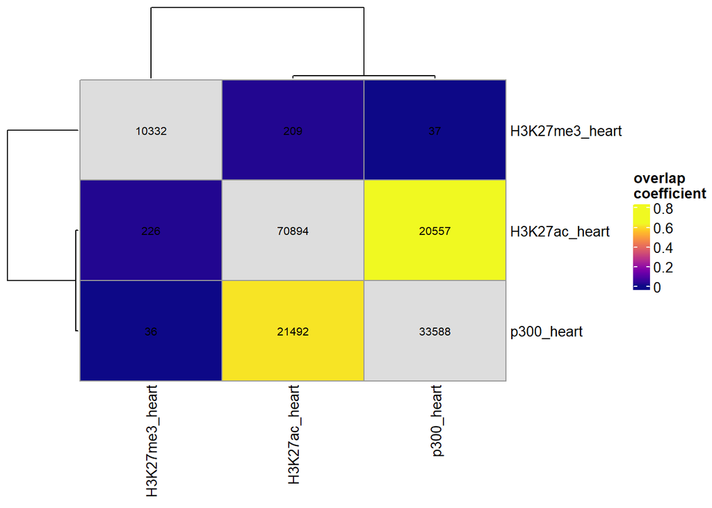

```r
# Visualizing overlaps between peaks in the heart
# As a heatmap of overlaps:
regionOverlaps(peaks_heart)
```

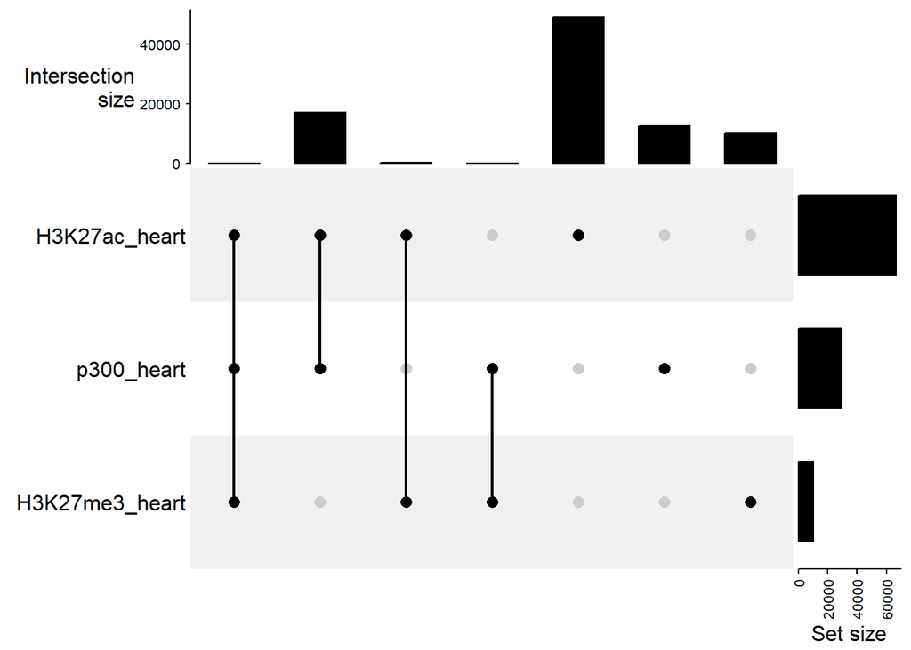

```r
# As an upset plot:
tmp <- regionsToUpset(peaks_heart, nsets=length(peaks_heart))
UpSet(make_comb_mat(regionsToUpset(peaks_heart, nsets=length(peaks_heart))))
```

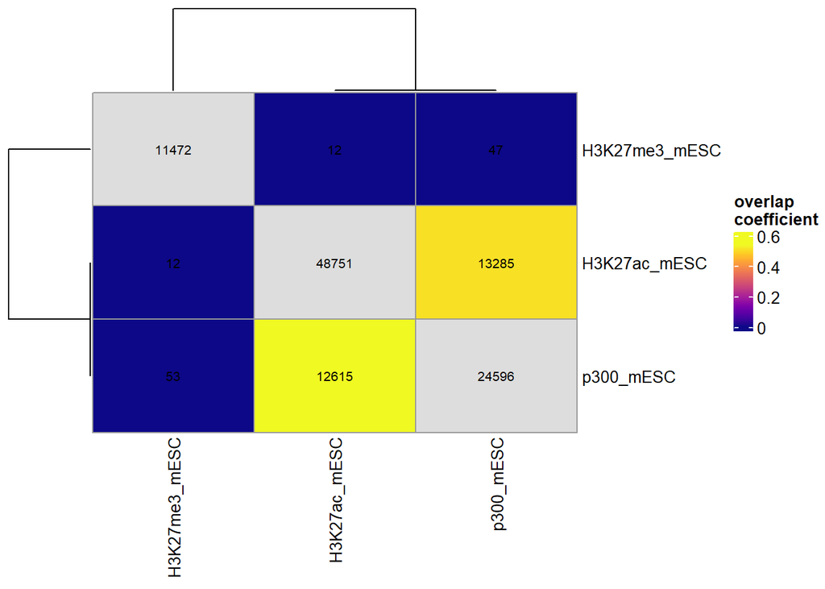

```r
# Visualizing overlaps between peaks in mESC
# As a heatmap of overlaps:
regionOverlaps(peaks_mESC)
```

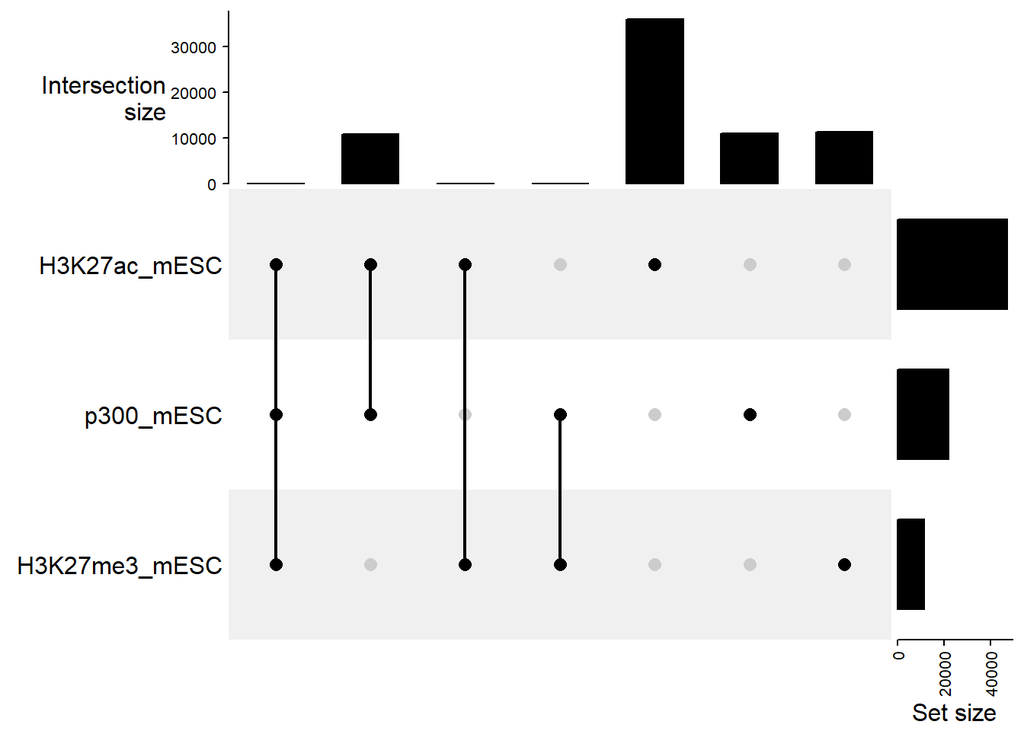

```r
# As an upset plot:
tmp <- regionsToUpset(peaks_mESC, nsets=length(peaks_mESC))
UpSet(make_comb_mat(regionsToUpset(peaks_mESC, nsets=length(peaks_mESC))))
```

## What is the relationship between regulatory elements active in mESC and in the differentiated tissue?

```r
peaks_p300 = peaks[grepl("p300", names(peaks))]
peaks_H3K27ac = peaks[grepl("H3K27ac", names(peaks))]
peaks_H3K27me3 = peaks[grepl("H3K27me3", names(peaks))]
```

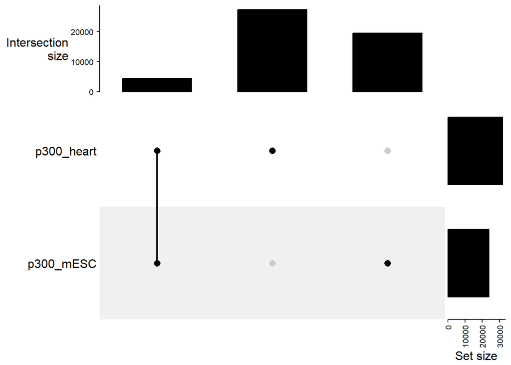

```r
# Visualizing overlaps between p300 peaks in the heart and mESC
# As an upset plot:
tmp <- regionsToUpset(peaks_p300, nsets=length(peaks_p300))
UpSet(make_comb_mat(regionsToUpset(peaks_p300, nsets=length(peaks_p300))))
```

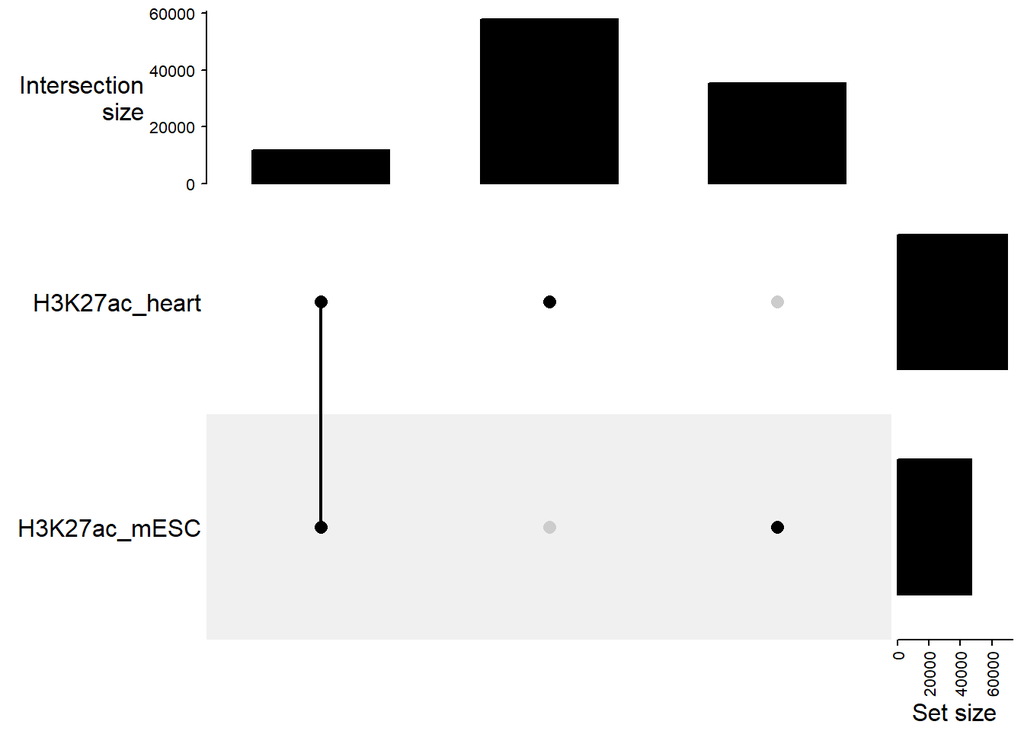

```r
# Visualizing overlaps between H3K27ac peaks in the heart and mESC
# As an upset plot:
tmp <- regionsToUpset(peaks_H3K27ac, nsets=length(peaks_H3K27ac))
UpSet(make_comb_mat(regionsToUpset(peaks_H3K27ac, nsets=length(peaks_H3K27ac))))
```

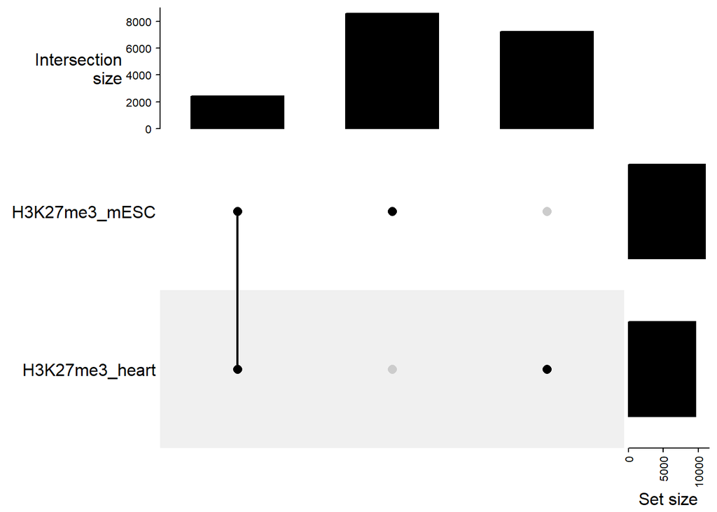

```r
# Visualizing overlaps between H3K27me3 peaks in the heart and mESC
# As an upset plot:
tmp <- regionsToUpset(peaks_H3K27me3, nsets=length(peaks_H3K27me3))
UpSet(make_comb_mat(regionsToUpset(peaks_H3K27me3, nsets=length(peaks_H3K27me3))))
```

# Observations

The above analysis offers several insights into the relationship between p300, H3K27ac, and H3K27me3 signals in differentiated and undifferentiated cells. Notably, p300 and H3K27ac peaks showed greater overlap than H3K27me3 peaks with either of the two signals. This pattern was observed in both the mESC and differentiated tissue datasets. It likely reflects the fact that p300 is a histone acetyltransferase that promotes H3K27ac deposition. It is well established that H3K27ac and H3K27me3 are mutually exclusive histone modifications: H3K27ac marks active enhancers and transcription start sites (TSS), whereas H3K27me3 is associated with repressed functional elements. In accordance to this, TSS analysis also showed limited overlap between H3K27ac and H3K27me3 signals. Additionally, TSS were more strongly associated with H3K27ac than with H3K27me3. Signal comparison between differentiated and undifferentiated cells showed relatively little overlap in signals between the two cell states. This is expected, as differentiation leads to significant changes in transcription and regulatory element activity, which manifests as different patterns of histone modifications and the binding of DNA-associated proteins like p300. Some overlap between the differentiated and undifferentiated states should be expected due to, for example, constant activity of housekeeping genes.